# Analyse descriptive et data mining

Mohamed Maftah (mohamed.maftah@polymtl.ca) & Mehdi Miah (mehdi.miah@gmail.com)

17-04-2018

**Descriptif** : sur le fichier des produits en ‘Electronics’, crée de nouvelles variables et recherche de l’information permettant de prédire le prix d’un article

# 1 Setup

```r
# Suppression des variables
rm(list = ls())

# Chargement des librairies
library(data.table) #pour fread
library(knitr) #pour le notebook
library(stringr) #pour l'analyse textuelle
library(ggplot2)
library(ggrepel) #pour geom_text_repel
library(tm) #pour le text mining (Corpus et etc)
library(wordcloud) #pour le nuage de mots
library(tau) #pour les n-grams
library(arules) #pour les règles d'association
library(tidyr)
library(dplyr)
```

# 2 Ouverture du fichier

```r
# Eléments considérés comme NA
na_strings = c(NA, '', '.', ' ', '?')

# Dataset au complet
dataset = fread("./data/intermediate/dataset_electronics.csv", data.table = FALSE,
                sep = ";", encoding = "UTF-8", na.strings = na_strings,
                colClasses = c("integer", "character", "factor", "factor", "factor", "factor",
                               "numeric", "integer", "character", "logical", "numeric"))
```

```r
head(dataset)
```

| train_id | name | item_condition_id | cat2 | cat3 | brand_name | price | shipping | item_description | is_brand_missing | log_price |
| --- | --- | --- | --- | --- | --- | --- | --- | --- | --- | --- |
| 1 | Razer BlackWidow Chroma Keyboard | 3 | Computers & Tablets | Components & Parts | otherBrand | 52 | 0 | This keyboard is in great condition and works like it came out of the box. All of the ports are tested and work perfectly. The lights are customizable via the Razer Synapse app on your PC. | FALSE | 3.970292 |
| 22 | Galaxy S7 Edge (Unlocked) 32GB | 3 | Cell Phones & Accessories | Cell Phones & Smartphones | Samsung | 386 | 0 | Reasonable offers welcomed. But if you ask “”“”lowest“”“” or lowball I’ll block you… - This phone was opened under T-Mobile but has now been unlocked after switching to new phone. - All of the buttons… | FALSE | 5.958425 |
| 23 | Triple car charger | 1 | Cell Phones & Accessories | Chargers & Cradles | brandMissing | 8 | 1 | Brand new never used All colors are available Each Only | TRUE | 2.197225 |
| 26 | Otterbox Defender iPhone 6 Plus/6s Plus | 1 | Cell Phones & Accessories | Cases, Covers & Skins | Apple | 13 | 1 | Brand new Otterbox Defender iPhone 6 Plus/6s Plus | FALSE | 2.639057 |
| 38 | XBOX One | 3 | Video Games & Consoles | Consoles | Xbox | 226 | 0 | 500GB Comes with power cord One controller with rechargeable pack and cord Comes with downloaded games The top is pretty scratched up but it doesn’t affect the gameplay | FALSE | 5.424950 |
| 59 | HV-900 sports Bluetooth headset | 1 | Cell Phones & Accessories | Headsets | brandMissing | 12 | 1 | New HV-900 sports sweatproof wireless Bluetooth 4.0 stereo headsets Earphone | TRUE | 2.564949 |

```r
str(dataset)
```

```
## 'data.frame':    122632 obs. of  11 variables:
##  $ train_id         : int  1 22 23 26 38 59 69 91 97 140 ...
##  $ name             : chr  "Razer BlackWidow Chroma Keyboard" "Galaxy S7 Edge (Unlocked) 32GB" "Triple car charger" "Otterbox Defender iPhone 6 Plus/6s Plus" ...
##  $ item_condition_id: Factor w/ 5 levels "1","2","3","4",..: 3 3 1 1 3 1 1 3 2 1 ...
##  $ cat2             : Factor w/ 8 levels "Cameras & Photography",..: 4 3 3 3 8 3 3 8 3 8 ...
##  $ cat3             : Factor w/ 51 levels "Accessories",..: 18 16 17 14 19 32 14 30 14 50 ...
##  $ brand_name       : Factor w/ 7 levels "Apple","Nintendo",..: 7 3 6 1 5 6 6 2 6 2 ...
##  $ price            : num  52 386 8 13 226 12 5 10 9 40 ...
##  $ shipping         : int  0 0 1 1 0 1 1 0 1 1 ...
##  $ item_description : chr  "This keyboard is in great condition and works like it came out of the box. All of the ports are tested and work"| __truncated__ "Reasonable offers welcomed. But if you ask \"\"\"\"lowest\"\"\"\" or lowball I'll block you... - This phone was"| __truncated__ "Brand new n…
##  $ is_brand_missing : logi  FALSE FALSE TRUE FALSE FALSE TRUE ...
##  $ log_price        : num  3.97 5.96 2.2 2.64 5.42 ...
```

# 3 Statistiques descriptives numériques

On reprend les statistiques et on les reéxécute sur les données totalement formatées et nettoyées. A partir de certains résultats, il sera possible de créer de nouvelles variables (features engineering).

## 3.1 Statistiques univariées

Quelle est la répartition des conditions des produits ?

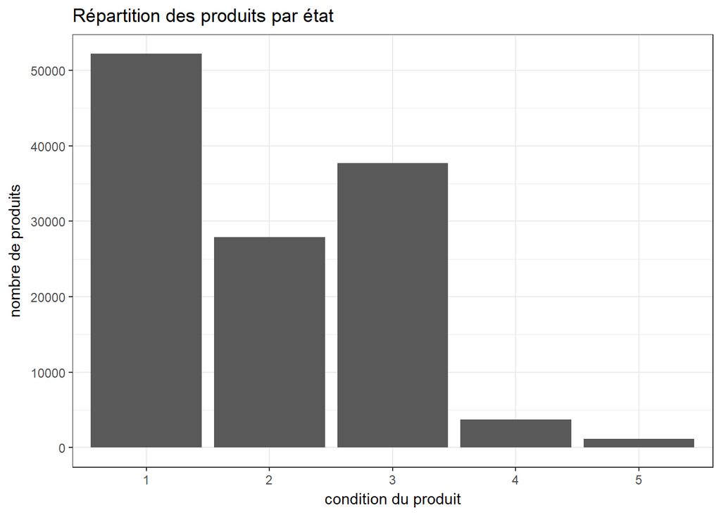

```r
# Dataframe comptant l'état des produits
n_articles_condition = dataset %>%
  group_by(item_condition_id) %>%
  summarise(effectif = n()) %>%
  ungroup()

# Graphique
ggplot(n_articles_condition, aes(x = item_condition_id, y = effectif)) +
  geom_bar(stat = 'identity') +
  labs(title = "Répartition des produits par état",
       x = "condition du produit",
       y = "nombre de produits") +
  theme_bw()
```

La très grande majorité des produits sont soit neufs (condition à 1), soit peu usés (condition à 2 et 3).

Quelle est la répartition par cat2 ?

```r
# Dataframe comptant le nombre de produits par cat2
n_articles_cat2 = dataset %>%
  group_by(cat2) %>%
  summarise(effectif = n()) %>% #nombre de produits
  ungroup() %>%
  mutate(pct = 100 * effectif / sum(effectif)) #pourcentage
```

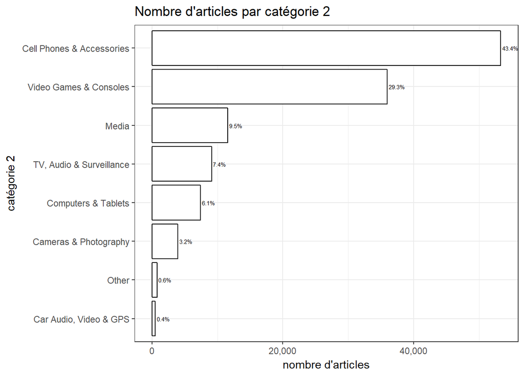

```r
# Ordonne les levels
n_articles_cat2$cat2 = factor(n_articles_cat2$cat2,
                              levels = n_articles_cat2$cat2[order(n_articles_cat2$effectif)])

# Graphique en barre
ggplot(n_articles_cat2, aes(x = cat2, y = effectif)) +
  geom_bar(stat = 'identity', fill = "white", color = "black") +
  labs(title = "Nombre d'articles par catégorie 2",
       x = "catégorie 2",
       y = "nombre d'articles") +
  geom_text(size = 2, hjust = -0.1, aes(y = effectif, label = sprintf("%.1f%%", pct))) +
  scale_y_continuous(labels = scales::comma) +
  coord_flip() +
  theme_bw()
```

Deux sous-catégories (cat2) apparaissent comme prédominants : les produits relatifs aux smartphones et aux jeux vidéos, qui représentent plus de 70% des articles proposés.

Quelle est la répartition par cat3 ?

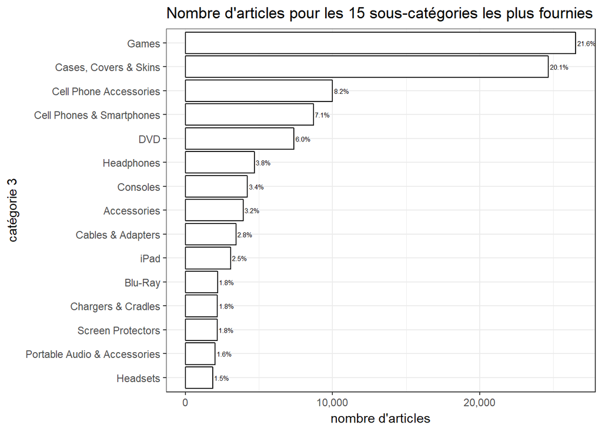

```r
# Dataframe comptant le nombre de produits par cat3
n_articles_cat3 = dataset %>%
  group_by(cat3) %>%
  summarise(effectif = n()) %>% #nombre de produits
  ungroup() %>%
  mutate(pct = 100 * effectif / sum(effectif)) %>% #pourcentage
  arrange(-effectif) #nécessaire pour ne sélectionner que les premiers

# Ordonne les levels
n_articles_cat3$cat3 = factor(n_articles_cat3$cat3,
                              levels = n_articles_cat3$cat3[order(n_articles_cat3$effectif)])

# Graphique en barre
n_head = 15
ggplot(n_articles_cat3 %>% head(n_head), aes(x = cat3, y = effectif)) +
  geom_bar(stat = 'identity', fill = "white", color = "black") +
  labs(title = paste("Nombre d'articles pour les", n_head, "sous-catégories les plus fournies"),
       x = "catégorie 3",
       y = "nombre d'articles") +
  geom_text(size = 2, hjust = -0.1, aes(y = effectif, label = sprintf("%.1f%%", pct))) +
  scale_y_continuous(labels = scales::comma) +
  coord_flip() +
  theme_bw()
```

Les résultats sont cohérents avec ceux obtenus à partir de la catégorie 2 : ici, nous voyons que les sous-catégories les plus fournies sont les jeux et les accessoires des smartphones (à eux-deux, elles représentent plus de 40% des articles en électronique).

Quelle est la structure des catégories ?

```r
structure_cat = dataset %>%
  select(cat2, cat3) %>%
  distinct() %>%
  arrange(cat2, cat3)

structure_cat
```

| cat2 | cat3 |
| --- | --- |
| Cameras & Photography | Binoculars & Telescopes |
| Cameras & Photography | Camcorders |
| Cameras & Photography | Camera & Photo Accessories |
| Cameras & Photography | Digital Cameras |
| Cameras & Photography | Film Photography |
| Cameras & Photography | Flashes & Flash Accessories |
| Cameras & Photography | Lenses & Filters |
| Cameras & Photography | Lighting & Studio |
| Cameras & Photography | Other |
| Cameras & Photography | Tripods & Supports |
| Car Audio, Video & GPS | Car Security & Convenience |
| Car Audio, Video & GPS | Car Speakers & Systems |
| Car Audio, Video & GPS | Car Stereos & Components |
| Car Audio, Video & GPS | Car Subwoofers |
| Car Audio, Video & GPS | Car Video |
| Car Audio, Video & GPS | GPS Accessories & Mounts |
| Car Audio, Video & GPS | GPS Units & Equipment |
| Car Audio, Video & GPS | Other |
| Car Audio, Video & GPS | Other Accessories |
| Cell Phones & Accessories | Batteries |
| Cell Phones & Accessories | Cables & Adapters |
| Cell Phones & Accessories | Cases, Covers & Skins |
| Cell Phones & Accessories | Cell Phone Accessories |
| Cell Phones & Accessories | Cell Phones & Smartphones |
| Cell Phones & Accessories | Chargers & Cradles |
| Cell Phones & Accessories | Headsets |
| Cell Phones & Accessories | Other |
| Cell Phones & Accessories | Screen Protectors |
| Computers & Tablets | Components & Parts |
| Computers & Tablets | Desktops & All-In-Ones |
| Computers & Tablets | Drives, Storage & Media |
| Computers & Tablets | Laptops & Netbooks |
| Computers & Tablets | Networking & Connectivity |
| Computers & Tablets | Other |
| Computers & Tablets | Printers, Scanners & Supplies |
| Computers & Tablets | iPad |
| Media | Blu-Ray |
| Media | CD |
| Media | DVD |
| Media | Other |
| Media | VHS |
| Other | Other |
| TV, Audio & Surveillance | DVD & Blu-ray Players |
| TV, Audio & Surveillance | Gadgets |
| TV, Audio & Surveillance | Headphones |
| TV, Audio & Surveillance | Home Audio |
| TV, Audio & Surveillance | Home Speakers & Subwoofers |
| TV, Audio & Surveillance | Home Surveillance |
| TV, Audio & Surveillance | Other |
| TV, Audio & Surveillance | Portable Audio & Accessories |
| TV, Audio & Surveillance | Televisions |
| Video Games & Consoles | Accessories |
| Video Games & Consoles | Consoles |
| Video Games & Consoles | Games |
| Video Games & Consoles | Other |
| Video Games & Consoles | Replacement Parts & Tools |
| Video Games & Consoles | Strategy Guides |
| Video Games & Consoles | Video Gaming Merchandise |

```r
# Nombre de familles de catégories
cat(sprintf("Il y a %.0f famille de catégories.\n", nrow(structure_cat)))
```

```
## Il y a 58 famille de catégories.
```

```r
# Nombre de modalités en cat2
cat(sprintf("Il y a %.0f modalités de cat2 uniques.\n", dataset$cat2 %>% unique() %>% length()))
```

```
## Il y a 8 modalités de cat2 uniques.
```

```r
# Nombre de modalités en cat3
cat(sprintf("Il y a %.0f modalités de cat3 uniques.\n", dataset$cat3 %>% unique() %>% length()))
```

```
## Il y a 51 modalités de cat3 uniques.
```

Nous retrouvons 58 familles de catégories (soit plus que les 51 modalités de **cat3**) car certaines proviennent de **cat2** différents comme la sous-catégorie *Other* qui est un enfant de 8 catégorie 2.

Quelles sont les marques les plus fréquentes ?

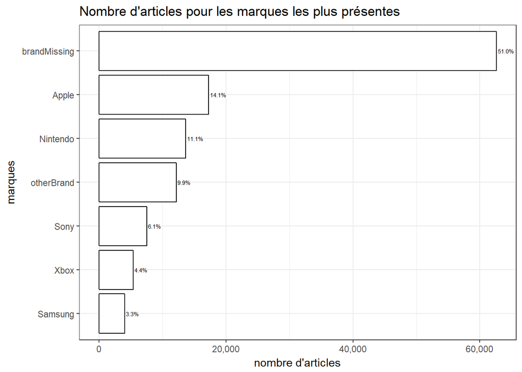

```r
# Dataframe comptant le nombre de produits par marque après agrégation des petites marques
n_articles_brand = dataset %>%
  group_by(brand_name) %>%
  summarise(effectif = n()) %>% #nombre de produits
  ungroup() %>%
  mutate(pct = 100 * effectif / sum(effectif)) %>% #pourcentage
  arrange(-effectif) #nécessaire pour ne sélectionner que les premiers

# Ordonne les levels
n_articles_brand$brand_name = factor(n_articles_brand$brand_name,
                                                levels = n_articles_brand$brand_name[order(n_articles_brand$effectif)])

# Graphique en barre
ggplot(n_articles_brand, aes(x = brand_name, y = effectif)) +
  geom_bar(stat = 'identity', fill = "white", color = "black") +
  labs(title = paste("Nombre d'articles pour les marques les plus présentes"),
       x = "marques",
       y = "nombre d'articles") +
  geom_text(size = 2, hjust = -0.1, aes(y = effectif, label = sprintf("%.1f%%", pct))) +
  scale_y_continuous(labels = scales::comma) +
  coord_flip() +
  theme_bw()
```

```r
# Nombre de marques différentes
cat(sprintf("Il y a %.0f marques différentes.\n", nrow(n_articles_brand)))
```

```
## Il y a 7 marques différentes.
```

Quelle est la répartition des prix ?

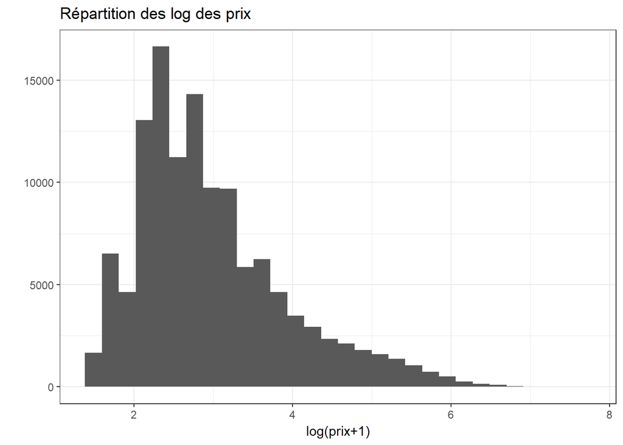

```r
# Histogramme du log des prix
ggplot(dataset, aes(x = log_price)) +
  geom_histogram() +
  labs(title = "Répartition des log des prix",
       x = "log(prix+1)",
       y = "") +
  theme_bw()
```

```r
# Etendue
summary(dataset$log_price)
```

```
##    Min. 1st Qu.  Median    Mean 3rd Qu.    Max.
##   1.386   2.303   2.773   2.988   3.466   7.555
```

Quelle est la répartition des frais de port ?

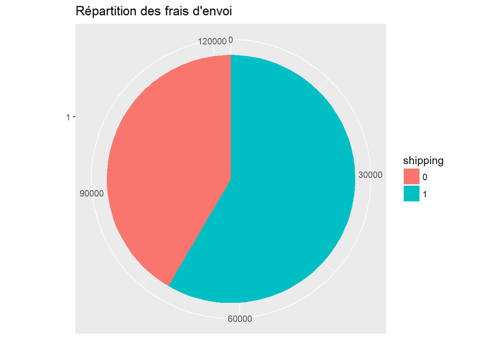

```r
# Dataframe comptant le nombre de produits par payeur des frais d'expédition
n_articles_shipping = dataset %>%
  group_by(shipping) %>%
  summarise(effectif = n()) %>% #nombre de produits
  ungroup()

# Mise en facteur de shipping
n_articles_shipping$shipping = n_articles_shipping$shipping %>% as.factor()

# Camembert
ggplot(n_articles_shipping, aes(x = factor(1) , y = effectif, fill = shipping)) +
  geom_bar(stat = 'identity', width = 1) +
  labs(title = "Répartition des frais d'envoi",
       x = "",
       y = "") +
  coord_polar(theta = "y")
```

## 3.2 Statistiques bivariées

Quel est l’effet du catégorie 2 sur le prix ?

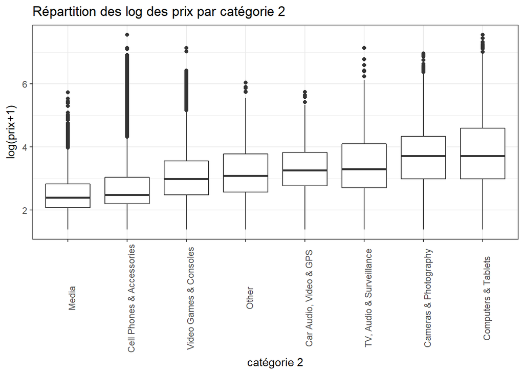

```r
# Prix médian par cat2
prix_median_cat2 = dataset %>%
  group_by(cat2) %>%
  summarise(prix_median = log_price %>% median()) %>%
  ungroup()

# Ordonne les cat2 par prix médian
dataset$cat2 = factor(dataset$cat2,
                      levels = prix_median_cat2$cat2[order(prix_median_cat2$prix_median)])

# Boxplot par cat2
ggplot(dataset, aes(x = cat2, y = log_price)) +
  geom_boxplot() +
  labs(title = "Répartition des log des prix par catégorie 2",
       x = "catégorie 2",
       y = "log(prix+1)") +
  theme_bw() +
  theme(axis.text.x = element_text(angle = 90))
```

Les catégories les moins chers (en médiane) : *Media* et *Cell Phones & Accessories* Les catégories les plus chers (en médiane) : *Camera & Photography* et *Computers & Tablets* Les catégories avec le plus d’outliers : *Cell Phones & Accessories*, *Media* et *Video Games & Consoles*

Quel est l’effet du catégorie 3 sur le prix ?

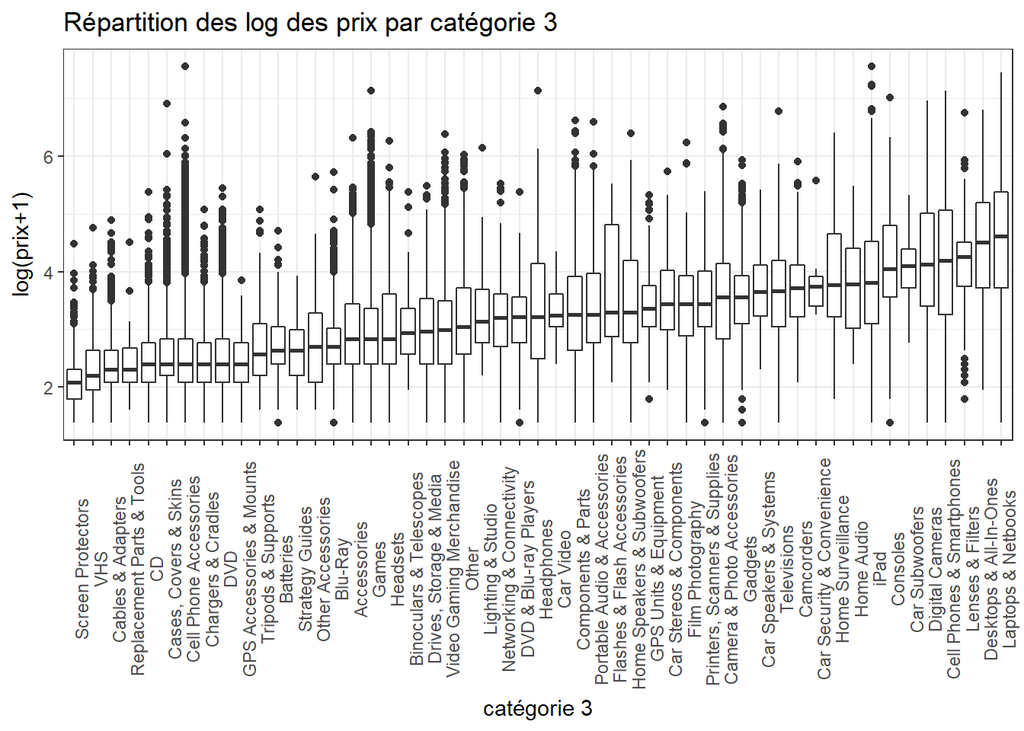

```r
# Prix médian par cat3
prix_median_cat3 = dataset %>%
  group_by(cat3) %>%
  summarise(prix_median = log_price %>% median()) %>%
  ungroup()

# Ordonne les cat3 par prix médian
dataset$cat3 = factor(dataset$cat3,
                      levels = prix_median_cat3$cat3[order(prix_median_cat3$prix_median)])

# Boxplot par cat3
ggplot(dataset, aes(x = cat3, y = log_price)) +
  geom_boxplot() +
  labs(title = "Répartition des log des prix par catégorie 3",
       x = "catégorie 3",
       y = "log(prix+1)") +
  theme_bw() +
  theme(axis.text.x = element_text(angle = 90))
```

Pas mal de variance dans chaque **cat3** : peut-être s’agit-il de produits mal classés ?

Quel est l’effet de la marque sur le prix ?

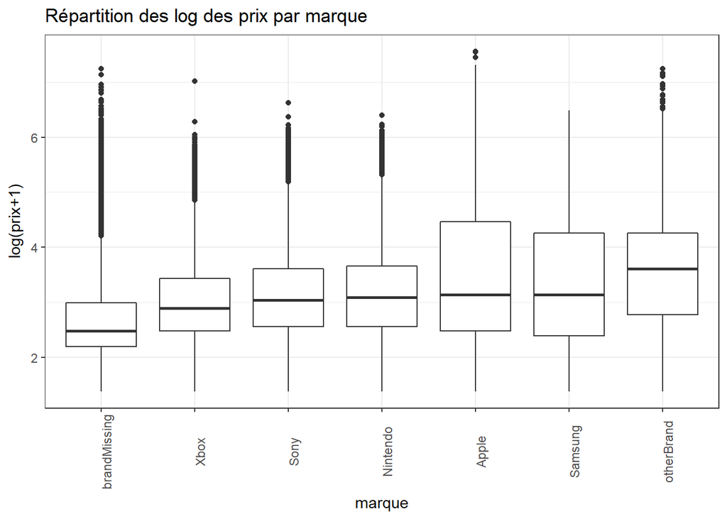

```r
# Prix médian par marque
prix_median_brand = dataset %>%
  group_by(brand_name) %>%
  summarise(prix_median = log_price %>% median()) %>%
  ungroup()

# Ordonne les brand_name par prix médian
dataset$brand_name = factor(dataset$brand_name,
                      levels = prix_median_brand$brand_name[order(prix_median_brand$prix_median)])

# Boxplot par brand_name
ggplot(dataset, aes(x = brand_name, y = log_price)) +
  geom_boxplot() +
  labs(title = "Répartition des log des prix par marque",
       x = "marque",
       y = "log(prix+1)") +
  theme_bw() +
  theme(axis.text.x = element_text(angle = 90))
```

Le fait de ne pas avoir de marque rend le produit moins cher : par exemple un accessoire ? A l’opposée, une marque autre que les 5 cités, entraîne une hausse des prix : par exemple Bose, Dr Dre, …

Quel est l’effet du condition du produit sur le prix ?

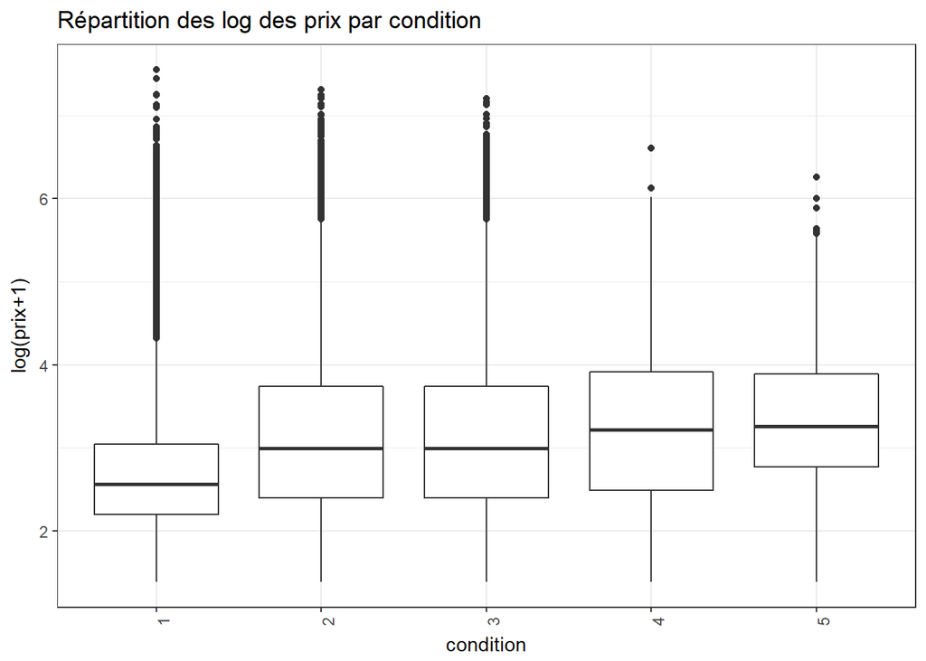

```r
# Boxplot par condition
ggplot(dataset, aes(x = item_condition_id, y = log_price)) +
  geom_boxplot() +
  labs(title = "Répartition des log des prix par condition",
       x = "condition",
       y = "log(prix+1)") +
  theme_bw() +
  theme(axis.text.x = element_text(angle = 90))
```

En médiane : plus le produit est d’occasion / usé, plus il cher !! Résultat étrange ! Cela s’explique peut-être par le fait qu’on mettra plus facilement un ordinateur d’occasion en vente (donc relativement cher) qu’un accessoire d’occasion. Bref, pour un produit d’occasion, seuls les produits relativement chers valent la peine d’être vendus.

TODO : refaire la stat par cat3 => montrer quu’il existe des produits mal classés

Regardons cela de plus près en regardant pour chaque **cat3** la part de produits d’occasion et le prix median. Notre hypothèse : plus un catégorie 3 voit de produits d’occasion (en proportion), plus il s’agit de produits chers.

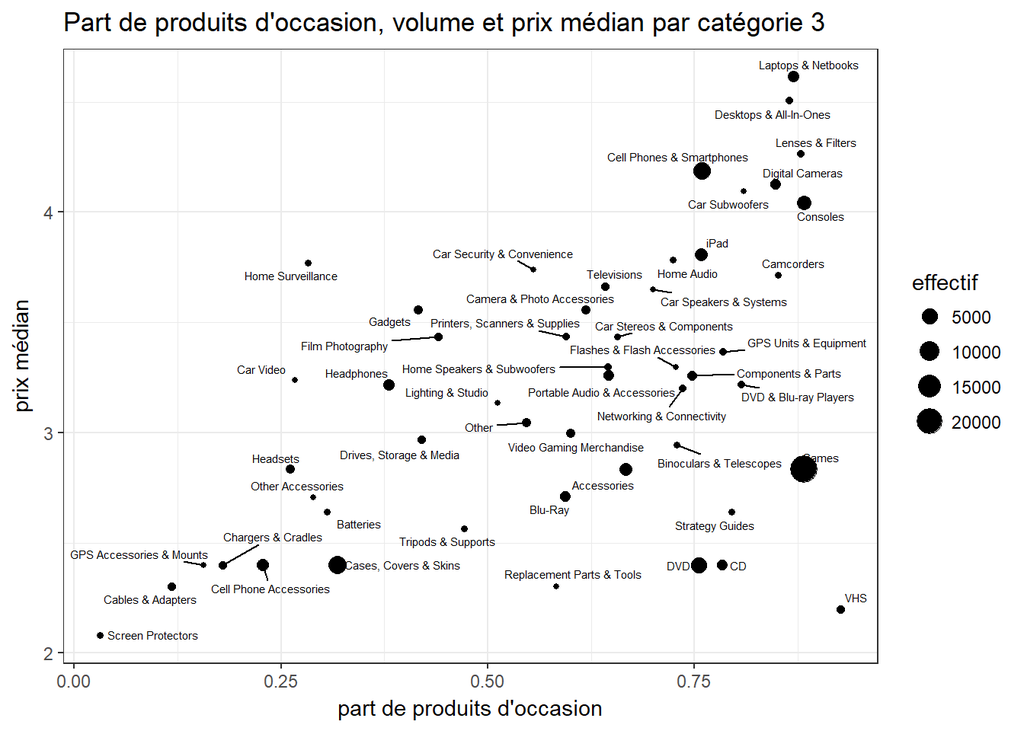

```r
# Part de produits d'occasion par cat3
part_occasion_cat3 = dataset %>%
  mutate(est_occasion = item_condition_id != 1) %>%
  group_by(est_occasion, cat3) %>%
  summarise(effectif = n()) %>% #pour chaque cat3, on a le nombre de produits neufs et d'occasion
  ungroup() %>%
  group_by(cat3) %>% #on va calculer la part d'occasion
  mutate(pct = effectif / sum(effectif)) %>%
  ungroup() %>%
  filter(est_occasion) %>% # on ne conserve que le taux de produits d'occasion et non celui des produits neufs
  select(-est_occasion)

# Statistiques par cat3
stat_cat3 = dataset %>%
  group_by(cat3) %>%
  summarise(prix_median = median(log_price)) %>%
  ungroup() %>%
  left_join(part_occasion_cat3, by = "cat3")

# Graphique où chaque point représente un cat3
ggplot(stat_cat3, aes(x = pct, y = prix_median)) +
  geom_point(aes(size = effectif)) +
  geom_text_repel(size = 2, vjust = -1, aes(x = pct, y = prix_median, label = cat3)) +
  labs(title = "Part de produits d'occasion, volume et prix médian par catégorie 3",
       x = "part de produits d'occasion",
       y = "prix médian") +
  theme_bw()
```

Il existe bien une corrélation positive entre part de produits d’occasion et prix de vente. Rajoutons cette variable dans la base de données.

```r
# Rajout de la part de produits d'occasion par cat3
dataset = dataset %>%
  left_join(part_occasion_cat3 %>% select(-effectif), by = "cat3")
```

Refaisons cette étude avec les catégories 2 :

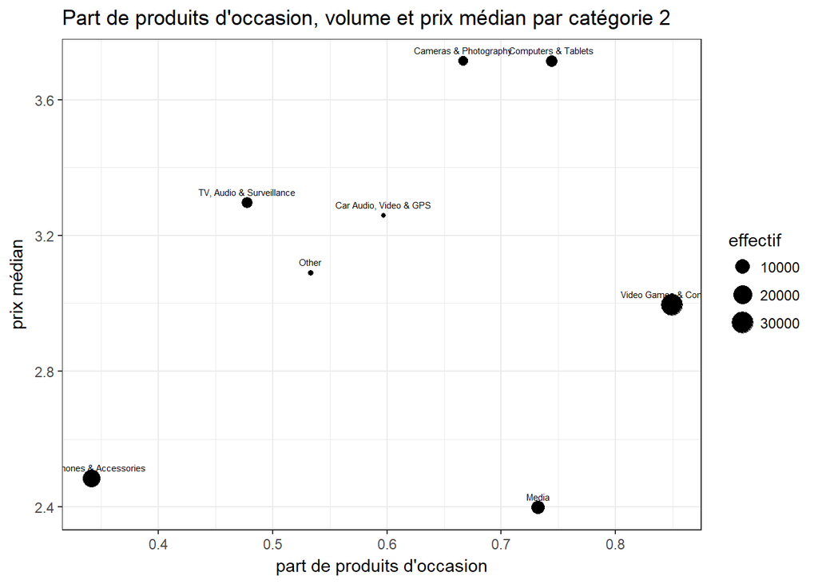

```r
# Part de produits d'occasion par cat2
part_occasion_cat2 = dataset %>%
  mutate(est_occasion = item_condition_id != 1) %>%
  group_by(est_occasion, cat2) %>%
  summarise(effectif = n()) %>% #pour chaque cat2, on a le nombre de produits neufs et d'occasion
  ungroup() %>%
  group_by(cat2) %>% #on va calculer la part d'occasion
  mutate(pct = effectif / sum(effectif)) %>%
  ungroup() %>%
  filter(est_occasion) %>% # on ne conserve que le taux de produits d'occasion et non celui des produits neufs
  select(-est_occasion)

# Statistiques par cat2
stat_cat2 = dataset %>%
  group_by(cat2) %>%
  summarise(prix_median = median(log_price)) %>%
  ungroup() %>%
  left_join(part_occasion_cat2, by = "cat2")

# Graphique où chaque point représente un cat3
ggplot(stat_cat2, aes(x = pct, y = prix_median)) +
  geom_point(aes(size = effectif)) +
  geom_text(size = 2, vjust = -1, aes(x = pct, y = prix_median, label = cat2)) +
  labs(title = "Part de produits d'occasion, volume et prix médian par catégorie 2",
       x = "part de produits d'occasion",
       y = "prix médian") +
  theme_bw()
```

Le résultat est semblable et fait ressortir les produits en *Video Games & Consoles* et en *Media*. En effet, par rapport à leur prix de vente médian, ces produits sont trop souvent vendus en occasion. Il s’agit vraisemblablement de produits qui font face à une concurrence dématérialisée. En effet, on devrait vendre moins d’occasion, donc plus de neufs. Or les produits neufs de ces deux catégories sont majoritairement vendus sur Steam ou sur Netflix. Le site de vente communautaire n’est alors plus en capacité de concurrencer ces vendeurs. De ce fait, les vendeurs ne vendent plus des produits neufs de ces types sur ce site.

Rajoutons le fait que le **cat2** soit concurrencés par des produits dématérialisés :

```r
# Listes des catégories 2 concurrencés par des produits dématérialisés
list_cat2_dematerialise = c("Media", "Video Games & Consoles")

dataset = dataset %>%
  mutate(cat2_dematerialise = cat2 %in% list_cat2_dematerialise)
```

Quel est l’effet des frais de port sur le prix ?

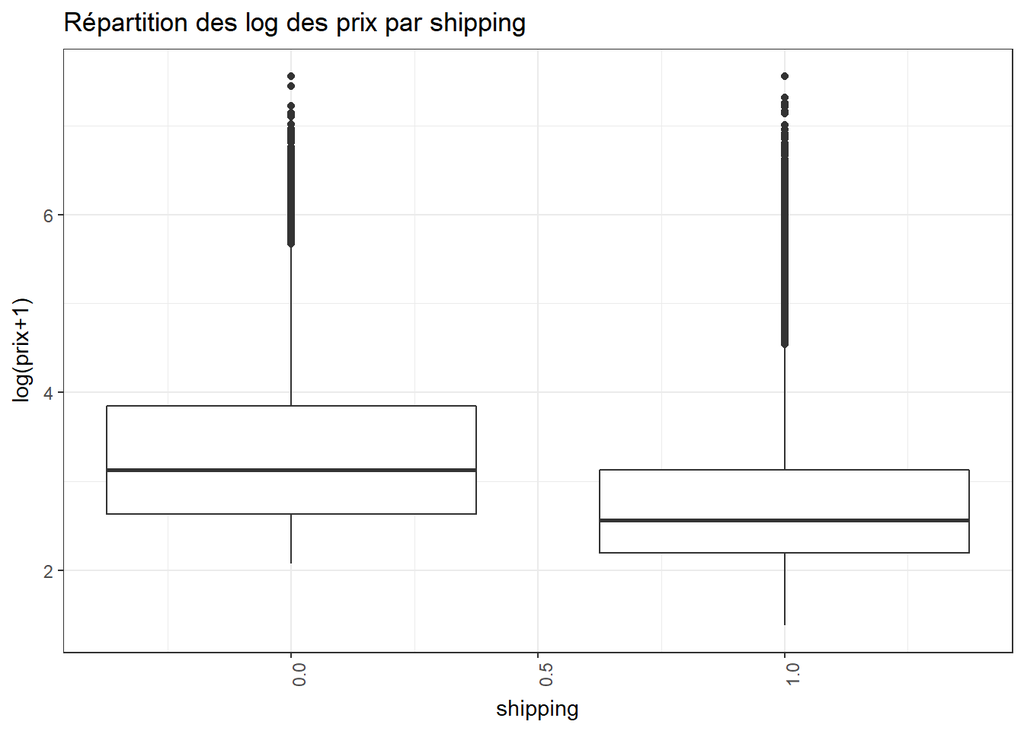

```r
# Boxplot par shipping
ggplot(dataset, aes(x = shipping, y = log_price, group = shipping)) +
  geom_boxplot() +
  labs(title = "Répartition des log des prix par shipping",
       x = "shipping",
       y = "log(prix+1)") +
  theme_bw() +
  theme(axis.text.x = element_text(angle = 90))
```

Avec ce niveau d’agrégation, on ne peut pas trop en tirer quelque chose (cf paradoxe de Simpson). Refaisons le même graphique par catégorie 2, voire catégorie 3.

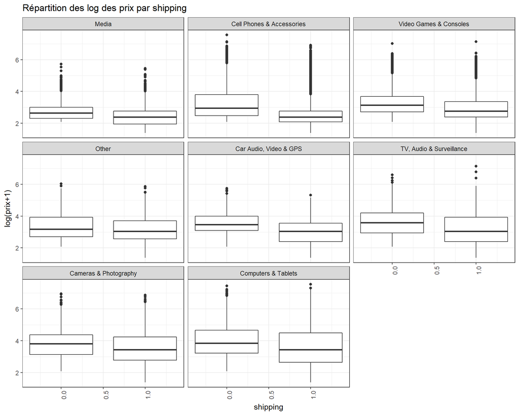

```r
# Boxplot par shipping par cat2
ggplot(dataset, aes(x = shipping, y = log_price, group = shipping)) +
  geom_boxplot() +
  labs(title = "Répartition des log des prix par shipping",
       x = "shipping",
       y = "log(prix+1)") +
  facet_wrap(~ cat2) +
  theme_bw() +
  theme(axis.text.x = element_text(angle = 90))
```

Ce résultat est étrange : shipping = 1 signifie que c’est le vendeur qui paie les frais d’expédition. A priori, si c’est lui qui les paie, le prix total devrait être plus élevé … Sauf s’il y a effet croisé entre **cat2** et **shipping** …

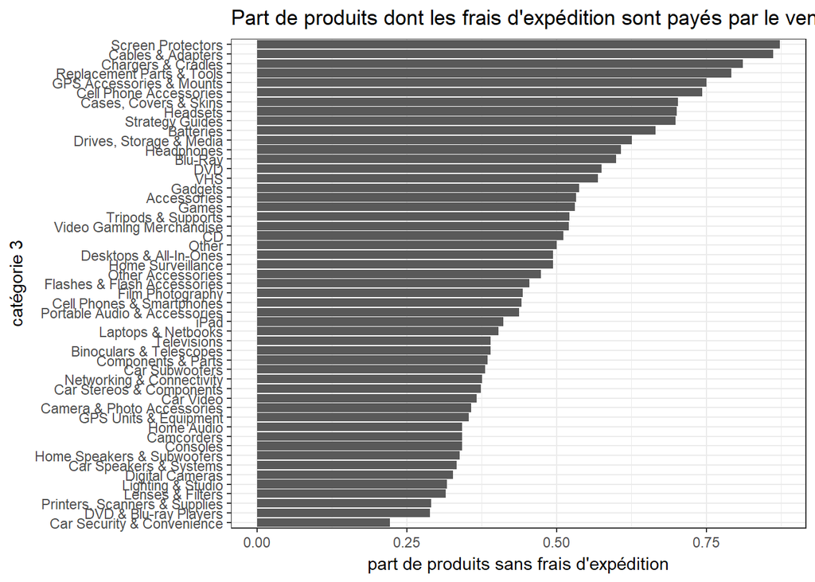

```r
# Part de produits dont les frais d'expédition sont payés par le vendeur par catégorie 3
part_shipping_cat3 = dataset %>%
  group_by(cat3) %>%
  summarise(part_shipping = mean(shipping)) %>%
  ungroup()

# Ordonne
part_shipping_cat3$cat3 = factor(part_shipping_cat3$cat3,
                              levels = part_shipping_cat3$cat3[order(part_shipping_cat3$part_shipping)])

# Diagramme en barre
ggplot(part_shipping_cat3, aes(x = cat3, y = part_shipping)) +
  geom_bar(stat = 'identity') +
  labs(title = "Part de produits dont les frais d'expédition sont payés par le vendeur par catégorie 3",
       x = "catégorie 3",
       y = "part de produits sans frais d'expédition") +
  coord_flip() +
  theme_bw()
```

Bof pas trop possible de voir ? Effet du prix ? de la condition ?

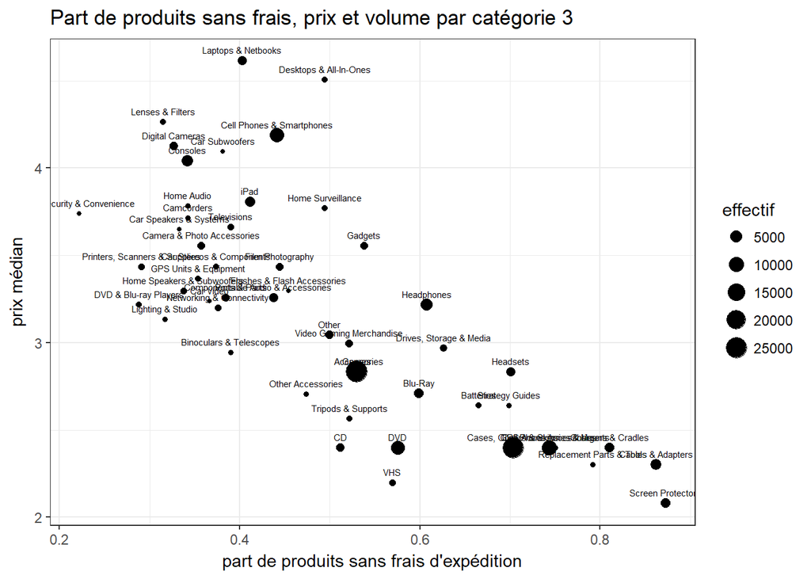

```r
# Stats sur les cat3
stat_cat3 = dataset %>%
  mutate(est_occasion = item_condition_id != 1) %>%
  group_by(cat3) %>%
  summarise(part_shipping = mean(shipping),
            part_occasion = mean(est_occasion),
            prix_median = median(log_price),
            effectif = n()) %>%
  ungroup()

# Graphique shipping x prix
ggplot(stat_cat3, aes(x = part_shipping, y = prix_median)) +
  geom_point(aes(size = effectif)) +
  geom_text(size = 2, vjust = -1, aes(label = cat3)) +
  labs(title = "Part de produits sans frais, prix et volume par catégorie 3",
       x = "part de produits sans frais d'expédition",
       y = "prix médian") +
  theme_bw()
```

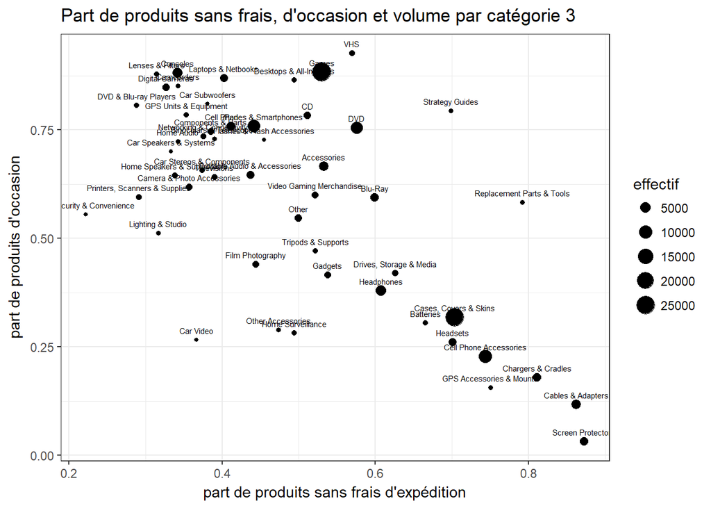

```r
# Graphique shipping x occasion
ggplot(stat_cat3, aes(x = part_shipping, y = part_occasion)) +
  geom_point(aes(size = effectif)) +
  geom_text(size = 2, vjust = -1, aes(label = cat3)) +
  labs(title = "Part de produits sans frais, d'occasion et volume par catégorie 3",
       x = "part de produits sans frais d'expédition",
       y = "part de produits d'occasion") +
  theme_bw()
```

# 4 Text mining

Quel est l’effet des majuscules ?

```r
# Pour chaque produit, on compte le nombre de caractères en minuscule et en majuscule, puis le ratio
name_maj = dataset %>%
  select(name, log_price) %>%
  mutate(n_chars_maj = sapply(str_match_all(name, "[A-Z]"), length),
         n_chars_min = sapply(str_match_all(name, "[a-z]"), length)) %>%
  mutate(ratio_maj_min = round(n_chars_maj/n_chars_min, 0)) #on arrondit por grouper dessus
```

On regarde le prix médian par niveau de ratio, arrondi à l’unité.

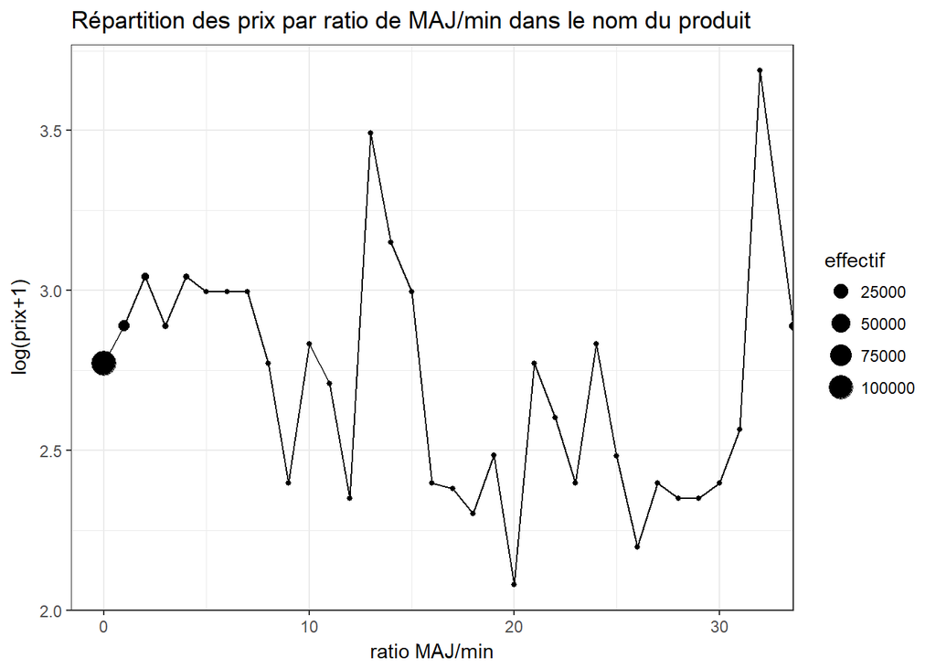

```r
# Groupe par ratio arrondi
prix_median_ratio_maj_min_name = name_maj %>%
  group_by(ratio_maj_min) %>%
  summarise(effectif = n(),
            prix_median = median(log_price)) %>%
  ungroup()

# Graphique par ratio arrondi
ggplot(prix_median_ratio_maj_min_name, aes(x = ratio_maj_min, y = prix_median)) +
  geom_line() +
  geom_point(aes(size = effectif)) +
  labs(title = "Répartition des prix par ratio de MAJ/min dans le nom du produit",
       x = "ratio MAJ/min",
       y = "log(prix+1)") +
  theme_bw()
```

De même dans la description :

```r
# Pour chaque produit, on compte le nombre de caractères en minuscule et en majuscule, puis le ratio
description_maj = dataset %>%
  select(item_description, log_price) %>%
  mutate(n_chars_maj = sapply(str_match_all(item_description, "[A-Z]"), length),
         n_chars_min = sapply(str_match_all(item_description, "[a-z]"), length)) %>%
  mutate(ratio_maj_min = round(n_chars_maj/n_chars_min, 0)) #on arrondit por grouper dessus
```

On regarde le prix médian par niveau de ratio, arrondi à l’unité.

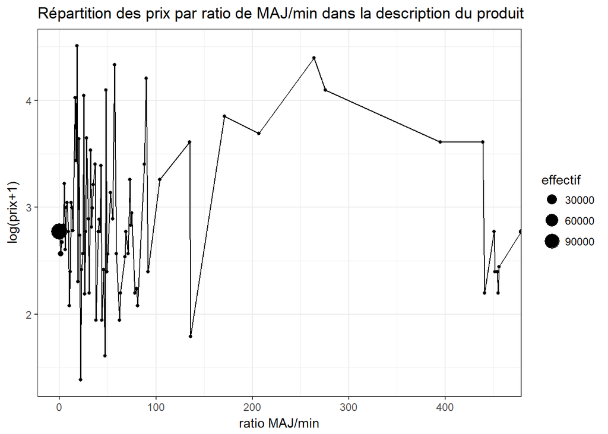

```r
# Groupe par ratio arrondi
prix_median_ratio_maj_min_description = description_maj %>%
  group_by(ratio_maj_min) %>%
  summarise(effectif = n(),
            prix_median = median(log_price)) %>%
  ungroup()

# Graphique par ratio arrondi
ggplot(prix_median_ratio_maj_min_description, aes(x = ratio_maj_min, y = prix_median)) +
  geom_line() +
  geom_point(aes(size = effectif)) +
  labs(title = "Répartition des prix par ratio de MAJ/min dans la description du produit",
       x = "ratio MAJ/min",
       y = "log(prix+1)") +
  theme_bw()
```

Il ne semble pas a priori avoir un effet de la casse.

## 4.1 Nuage de mots

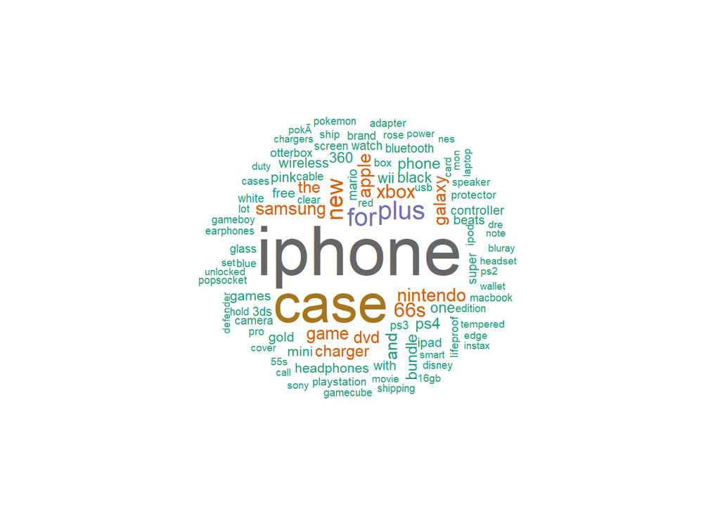

```r
# Inspiré de :
# http://www.sthda.com/french/wiki/text-mining-et-nuage-de-mots-avec-le-logiciel-r-5-etapes-simples-a-savoir
# https://datascienceplus.com/building-wordclouds-in-r/
# https://www.r-bloggers.com/24-days-of-r-day-11/ (n-grams avec <tau>)

# Création du corpus de noms de produits
corpus_name = Corpus(VectorSource(dataset$name) ,list(language = "english"))
corpus_name = tm_map(corpus_name, tolower)
corpus_name = tm_map(corpus_name, removePunctuation)
corpus_name = tm_map(corpus_name, stripWhitespace)

# Suppression des mots stopwords
myStopwords = c(stopwords('english'))
#corpus_name = tm_map(corpus_name, removeWords, myStopwords)

# Nuage de mots
wordcloud(corpus_name, max.words = 100, random.order = FALSE, min.freq = 10, colors = brewer.pal(8, "Dark2"))
```

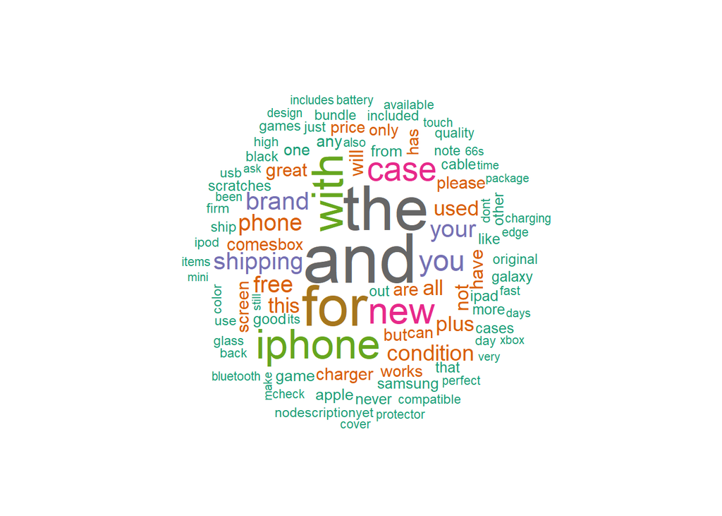

```r
# Inspiré de :
# http://www.sthda.com/french/wiki/text-mining-et-nuage-de-mots-avec-le-logiciel-r-5-etapes-simples-a-savoir
# https://datascienceplus.com/building-wordclouds-in-r/
# https://www.r-bloggers.com/24-days-of-r-day-11/ (n-grams avec <tau>)

# Création du corpus de descriptions de produits
corpus_description = Corpus(VectorSource(dataset$item_description) ,list(language = "english"))
corpus_description = tm_map(corpus_description, tolower)
corpus_description = tm_map(corpus_description, removePunctuation)
corpus_description = tm_map(corpus_description, stripWhitespace)

# Suppression des mots stopwords
myStopwords = c(stopwords('english'))
#corpus_description = tm_map(corpus_description, removeWords, myStopwords)

# Nuage de mots
wordcloud(corpus_description, max.words = 100, random.order = FALSE, min.freq = 10, colors = brewer.pal(8, "Dark2"))
```

Faut-il laisser les for et les with ? TODO : à avoir TODO : bigrams / trigrams TODO : lemmatiser ?

### 4.1.1 Vue d’ensemble par variable textuelle

Affichons les mots les plus utilsés dans les noms des produits.

```r
freqwords_name = textcnt(corpus_name, n = 1, method = "string")
freqwords_name = freqwords_name[order(freqwords_name, decreasing = TRUE)]
freqwords_name[1:50]
```

```
##      iphone        case           s        plus         for         new
##       30232       22669       16991        9847        8239        7173
##          ps        xbox    nintendo       apple     samsung        game
##        6529        5524        5124        4674        4591        4481
##      galaxy          ds         dvd         the     charger          of
##        4359        4236        4163        4052        3775        3631
##         and          gb      bundle       phone       black         one
##        3604        3476        3421        3358        3234        3137
##         wii           x    wireless        pink        free       games
##        2849        2771        2703        2522        2453        2390
##        gold  headphones        mini        ipad        with       beats
##        2345        2324        2294        2229        2164        2121
##       mario  controller   bluetooth       watch       super       glass
##        2093        2014        1897        1827        1792        1691
##      screen       cable       white      camera       brand    otterbox
##        1680        1660        1565        1542        1533        1486
## playstation         usb
##        1456        1448
```

Affichons les mots les plus utilisés dans les descriptions des produits.

```r
freqwords_description = textcnt(corpus_description, n = 1, method = "string")
freqwords_description = freqwords_description[order(freqwords_description, decreasing = TRUE)]
freqwords_description[1:50]
```

```
##       and       the       for      with    iphone        to         a
##     95589     84591     75962     55251     52642     51790     50962
##        in        is       new         s      case       you        it
##     46391     45187     44879     42333     39066     31994     31625
##        of         i        on  shipping     brand      your      plus
##     29983     26987     25927     25051     25015     24697     24640
##     phone      free condition        or      this       all      used
##     23427     22520     21220     20771     20661     20232     19209
##        no      will       not      have     great       are     comes
##     18944     17233     17111     16555     16425     15591     14006
##       but   charger    screen        my    please       box     works
##     13769     13694     13602     13334     13158     12886     12715
##       can       has         x      only       one       any        as
##     12529     12442     12324     12250     11921     11914     11896
##     price
##     11879
```

### 4.1.2 Bigrams

```r
freqbigrams_name = textcnt(corpus_name, n = 2, method = "string")
freqbigrams_name = freqbigrams_name[order(freqbigrams_name, decreasing = TRUE)]
freqbigrams_name[1:50]
```

```
##          iphone s       iphone plus            s plus          galaxy s
##             11308              5962              3017              2668
##            s case    samsung galaxy          xbox one         plus case
##              2567              2536              2533              2220
##       iphone case       nintendo ds        for iphone        phone case
##              2154              2124              2028              1512
##         brand new          case for         free ship       case iphone
##              1473              1307              1083              1032
##     free shipping         rose gold       apple watch  screen protector
##              1016               996               962               911
##       super mario      apple iphone    tempered glass         ipad mini
##               876               859               853               815
##          iphone c           call of           of duty            s edge
##               810               803               800               778
##            plus s        kate spade          beats by    iphone charger
##               749               667               661               638
##       smart watch           blu ray           on hold             wii u
##               624               617               617               595
##       instax mini       wallet case           ds game         otter box
##               585               581               556               551
##            by dre       rubber case       galaxy note        beats solo
##               521               519               516               503
##          x iphone         black ops            for ps otterbox defender
##               494               471               467               462
##         star wars   gameboy advance
##               460               459
```

A voir si intégrable dans le dfm()

## 4.2 Mots et catégories de prix

On remarque que les mots les plus utilisés sont les noms de produits. Quels sont les produits valorisés et les autres ? On regroupe par catégorie 3, et par tranche de prix. Ensuite, on fait un nuage de mots pour déterminer les mots “positifs” des mots “négatifs”

```r
# On crée une nouvelle variable qui indique si le produit fait partie des produits chers ou peu chers

# Pour identifier les produits (très) chers es autres, il est nécessaire de connaitre la fonction de répartition des prix, pour voir à partir de quel quantile les prix explosent
quantile(dataset$price, probs = seq(from = 0, to = 1, by = 0.05))
```

```
##   0%   5%  10%  15%  20%  25%  30%  35%  40%  45%  50%  55%  60%  65%  70%
##    3    5    6    7    8    9   10   11   12   14   15   16   19   22   25
##  75%  80%  85%  90%  95% 100%
##   31   39   51   76  140 1909
```

```r
# Il n'y a pas de cut précis à prendre. On y va au doigt mouillé : 25%-50%-75%
# On cré 3 catégories de prix sur l'ensemble des produits
dataset = dataset %>%
  mutate(sentence = paste(name, brand_name)) %>%
  mutate(quant = cut(x      = log_price,
                     breaks = quantile(log_price, probs = c(0, 0.25, 0.75, 1)),
                     include.lowest = TRUE,
                     labels = c("Cheap", "Moderate", "Expensive")
                     )
         )
```

Quels sont les mots employés dans les produits chers ?

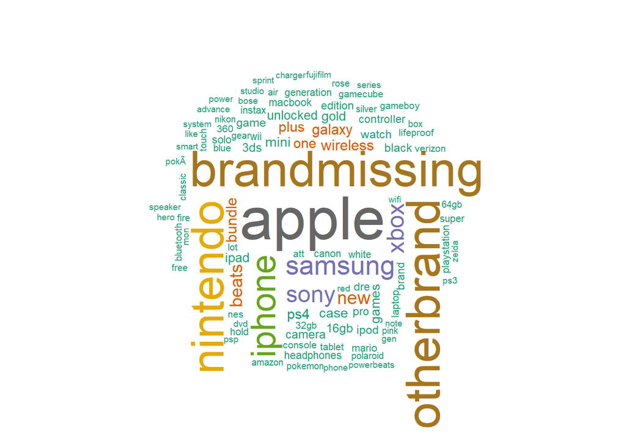

```r
# Création du corpus des produits chers
corpus_expensive = Corpus(VectorSource(dataset$sentence[dataset$quant == "Expensive"]),
                          list(language = "english"))
corpus_expensive = tm_map(corpus_expensive, tolower)
corpus_expensive = tm_map(corpus_expensive, removePunctuation)
corpus_expensive = tm_map(corpus_expensive, stripWhitespace)

# Suppression des mots stopwords
myStopwords = c(stopwords('english'))
corpus_expensive = tm_map(corpus_expensive, removeWords, myStopwords)

# Nuage de mots
wordcloud(corpus_expensive, max.words = 100, random.order = FALSE,
          min.freq = 10, colors = brewer.pal(8, "Dark2"))
```

Où est-ce qu’on trouve le mot apple ? ou iphone ?

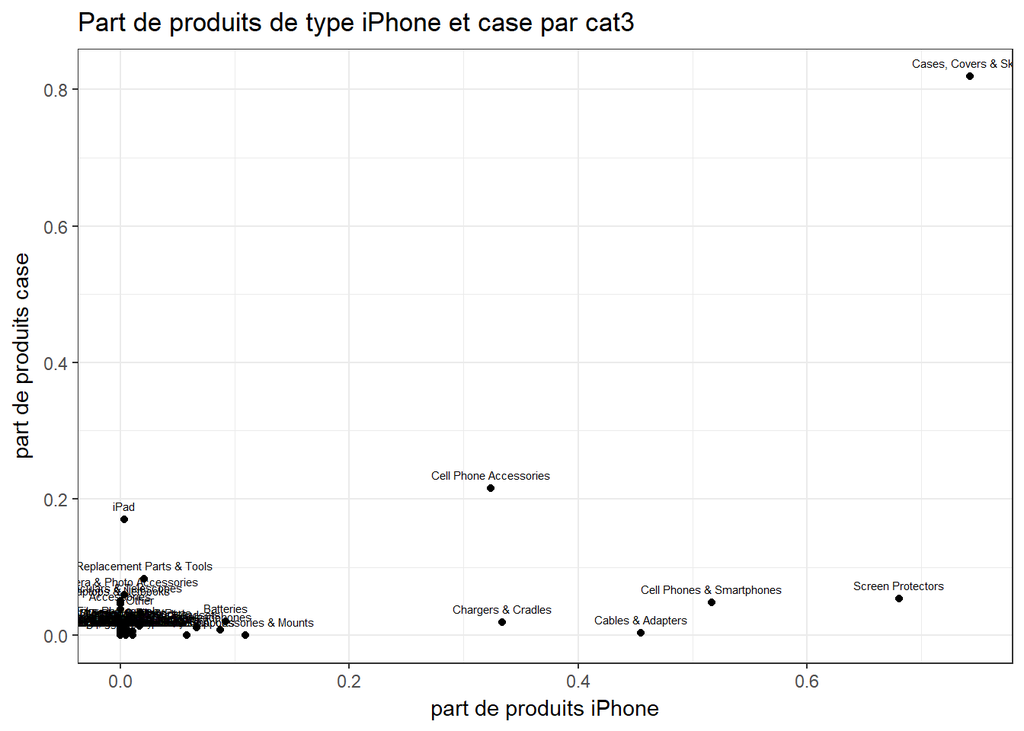

```r
# Calcul de la part de produit Iphone et Case dans chaque cat3
localisation_iphone_case = dataset %>%
  mutate(a_iphone = grepl(pattern = "iphone", x = tolower(name)),
         a_case = grepl(pattern = "case", x = tolower(name))) %>%
  group_by(cat3) %>%
  summarise(pct_iphone = mean(a_iphone),
            pct_case = mean(a_case)) %>%
  ungroup()

# Graphique en barre
ggplot(localisation_iphone_case, aes(x = pct_iphone, y = pct_case)) +
  geom_point() +
  geom_text(size = 2, vjust = -1, aes(label = cat3)) +
  labs(title = "Part de produits de type iPhone et case par cat3",
       x = "part de produits iPhone",
       y = "part de produits case") +
  theme_bw()
```

Quels sont les mots employés dans les produits à prix modéré ?

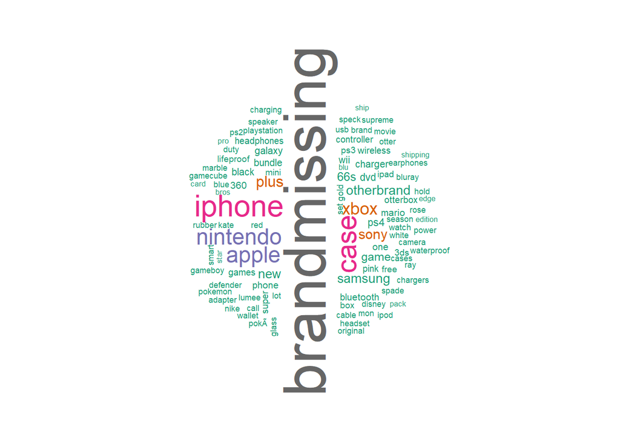

```r
# Création du corpus des produits à prix modéré
corpus_moderate = Corpus(VectorSource(dataset$sentence[dataset$quant == "Moderate"]),
                          list(language = "english"))
corpus_moderate = tm_map(corpus_moderate, tolower)
corpus_moderate = tm_map(corpus_moderate, removePunctuation)
corpus_moderate = tm_map(corpus_moderate, stripWhitespace)

# Suppression des mots stopwords
myStopwords = c(stopwords('english'))
corpus_moderate = tm_map(corpus_moderate, removeWords, myStopwords)

# Nuage de mots
wordcloud(corpus_moderate, max.words = 100, random.order = FALSE,
          min.freq = 10, colors = brewer.pal(8, "Dark2"))
```

Quels sont les mots employés dans les produits à prix bas ?

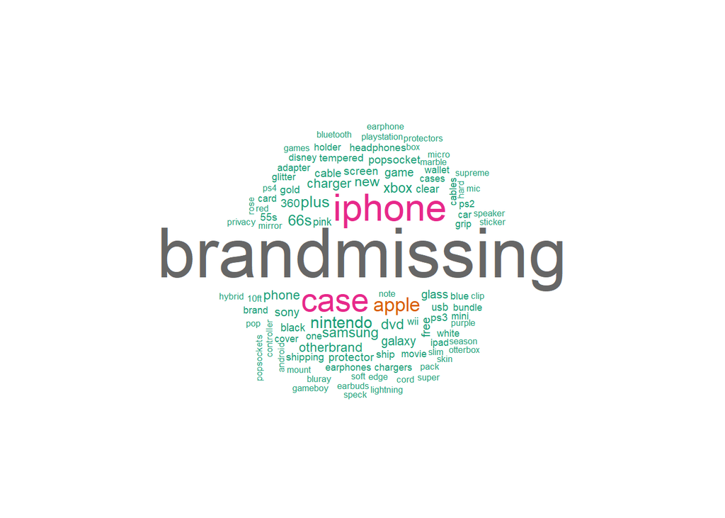

```r
# Création du corpus des produits à prix bas
corpus_cheap = Corpus(VectorSource(dataset$sentence[dataset$quant == "Cheap"]),
                          list(language = "english"))
corpus_cheap = tm_map(corpus_cheap, tolower)
corpus_cheap = tm_map(corpus_cheap, removePunctuation)
corpus_cheap = tm_map(corpus_cheap, stripWhitespace)

# Suppression des mots stopwords
myStopwords = c(stopwords('english'))
corpus_cheap = tm_map(corpus_cheap, removeWords, myStopwords)

# Nuage de mots
wordcloud(corpus_cheap, max.words = 100, random.order = FALSE,
          min.freq = 10, colors = brewer.pal(8, "Dark2"))
```

## 4.3 Règles d’association

Il faut déterminer quel mot implique “Expensive” ou “Cheap”

```r
# Matrice Documents x Terms

# On réexploite le corpus crée à partir des noms des produits
ndocs = length(corpus_name)

# Suppression des mots rares de la matrice
## On supprime les mots rares poué éviter que la matrice n'explose en mémoire
min_support = 0.001
minDocFreq = ndocs * min_support

myDtmUnigram = DocumentTermMatrix(corpus_name, control = list(bounds = list(global = c(minDocFreq,ndocs)),
                                                              weighting = "weightBin"))

m = as.matrix(myDtmUnigram) #mise en matrice
m = data.frame( m > 0) #binarisation
dim(m) #le nombre de colonne indique le nombre de mots
```

```
## [1] 122632    505
```

```r
# On rajoute la colonne indiquant la catégorie de prix
m$quant = dataset$quant
```

```r
# On doit une matrice totalement binaire (la variable quant est catégorielle)
trans = as(m, "transactions")
summary(trans)
```

```
## transactions as itemMatrix in sparse format with
##  122632 rows (elements/itemsets/transactions) and
##  508 columns (items) and a density of 0.007828042
##
## most frequent items:
##  quant=Moderate     quant=Cheap quant=Expensive          iphone
##           60599           32149           29884           29513
##            case         (Other)
##           22543          312976
##
## element (itemset/transaction) length distribution:
## sizes
##     1     2     3     4     5     6     7     8     9
##  4838 16737 27842 28906 23171 14603  5604   878    53
##
##    Min. 1st Qu.  Median    Mean 3rd Qu.    Max.
##   1.000   3.000   4.000   3.977   5.000   9.000
##
## includes extended item information - examples:
##     labels variables levels
## 1 keyboard  keyboard   TRUE
## 2    X32gb     X32gb   TRUE
## 3     edge      edge   TRUE
##
## includes extended transaction information - examples:
##   transactionID
## 1             1
## 2             2
## 3             3
```

```r
# On souhaite les règles qui implique quant=Cheap ou quant=Expensive
# En effet, Moderate comprend 50% des données...
quant_family = paste0("quant=", unique(m$quant))
quant_family = setdiff(quant_family, "quant=Moderate")

rules = apriori(trans,
                parameter = list(target = "rules", support = 0.001, confidence = 0.8, maxlen = 4),
                appearance = list(rhs = c(quant_family))
)
```

```
## Apriori
##
## Parameter specification:
##  confidence minval smax arem  aval originalSupport maxtime support minlen
##         0.8    0.1    1 none FALSE            TRUE       5   0.001      1
##  maxlen target   ext
##       4  rules FALSE
##
## Algorithmic control:
##  filter tree heap memopt load sort verbose
##     0.1 TRUE TRUE  FALSE TRUE    2    TRUE
##
## Absolute minimum support count: 122
##
## set item appearances ...[2 item(s)] done [0.00s].
## set transactions ...[508 item(s), 122632 transaction(s)] done [0.05s].
## sorting and recoding items ... [508 item(s)] done [0.01s].
## creating transaction tree ... done [0.10s].
## checking subsets of size 1 2 3 4
```

```
##  done [0.03s].
## writing ... [82 rule(s)] done [0.00s].
## creating S4 object  ... done [0.02s].
```

```r
arules::inspect(sort(rules, by = "confidence"))
```

```
##      lhs                           rhs               support
## [1]  {wireless,beats,solo}      => {quant=Expensive} 0.001720595
## [2]  {unlocked,iphone,X16gb}    => {quant=Expensive} 0.001051928
## [3]  {wireless,solo}            => {quant=Expensive} 0.001810294
## [4]  {unlocked,X16gb}           => {quant=Expensive} 0.001141627
## [5]  {wireless,dre}             => {quant=Expensive} 0.001598278
## [6]  {galaxy,unlocked}          => {quant=Expensive} 0.001060082
## [7]  {wireless,beats}           => {quant=Expensive} 0.005072086
## [8]  {wireless,powerbeats}      => {quant=Expensive} 0.001369952
## [9]  {wireless,beats,dre}       => {quant=Expensive} 0.001337334
## [10] {iphone,sprint}            => {quant=Expensive} 0.001263944
## [11] {iphone,X64gb}             => {quant=Expensive} 0.001997847
## [12] {edition,classic}          => {quant=Expensive} 0.001068237
## [13] {edition,nes}              => {quant=Expensive} 0.001035619
## [14] {edition,nes,classic}      => {quant=Expensive} 0.001019310
```

[output cut: 151 more lines]